# Modeling and prediction for movies

## Setup

### Load packages

```r
library(ggplot2)
library(dplyr)
library(statsr)
library(MASS)
```

### Load data

Make sure your data and R Markdown files are in the same directory. When loaded your data file will be called `movies`. Delete this note when before you submit your work.

```r
load("movies.Rdata")
```

## Part 1: Data

The data contains 651 randomly sampled movies released before 2016. So study based on the data would has generablizability. However, movies are rated by volunteers, so the data may contain volunteer bais. Data is not generated from experiment, it could only be used in oberservational study. So causality can not found from the data.

## Part 2: Research question

what kind of variable affect imbd rating. Are imbd ratings infulenced by some other indicators besides movies’ contents? And what are these indicators?

It is interesting to know whether movie’s rating depends on its quality or some other kind of staff.

## Part 3: Exploratory data analysis

First, let’s explore the distribution of the imdb rating.

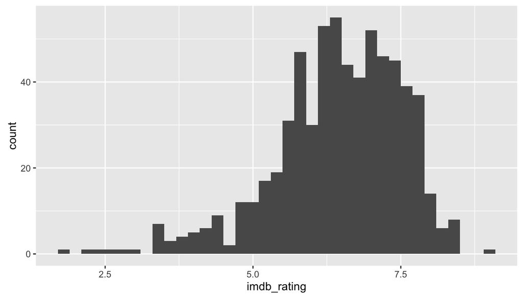

```r
ggplot(movies, aes(x = imdb_rating)) + geom_histogram(binwidth = 0.2)
```

```r
summary(movies$imdb_rating)
```

```
##    Min. 1st Qu.  Median    Mean 3rd Qu.    Max.
##   1.900   5.900   6.600   6.493   7.300   9.000
```

Consider the correlation with audience_score and imdb_rating.

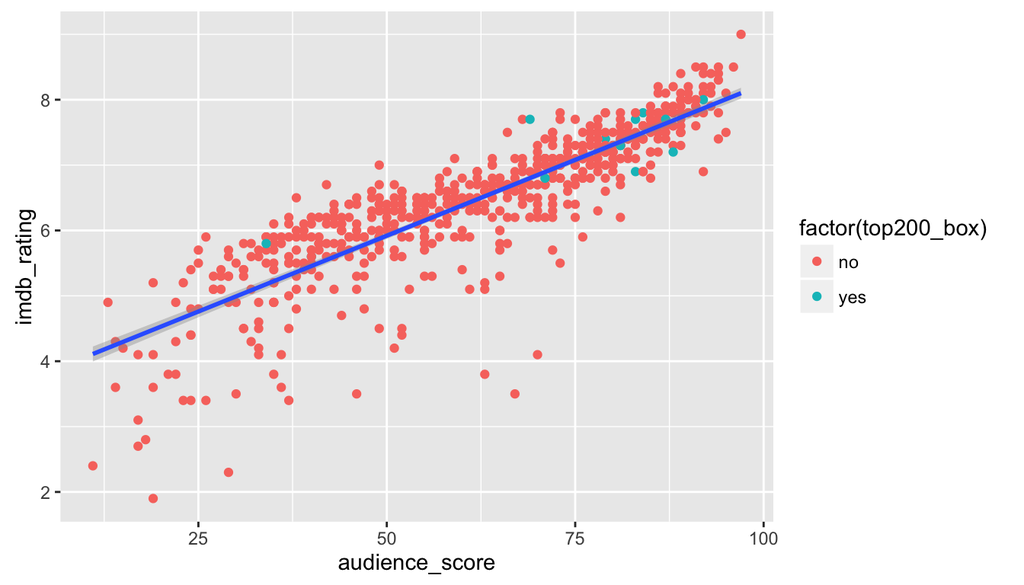

```r
ggplot(data = movies, aes(x = audience_score, y = imdb_rating))  +
  geom_point(aes(colour = factor(top200_box))) +
  geom_smooth(method = "lm")
```

From the scatter plot, we could see a strong linear correlation between aduience_score and imdb_rating.

```r
lm1 <- lm(imdb_rating ~ audience_score, movies)
summary(lm1)
```

```
##
## Call:
## lm(formula = imdb_rating ~ audience_score, data = movies)
##
## Residuals:
##     Min      1Q  Median      3Q     Max
## -3.2082 -0.1866  0.0712  0.3093  1.1516
##
## Coefficients:
##                Estimate Std. Error t value Pr(>|t|)
## (Intercept)    3.599992   0.069291   51.95   <2e-16 ***
## audience_score 0.046392   0.001057   43.89   <2e-16 ***
## ---
## Signif. codes:  0 '***' 0.001 '**' 0.01 '*' 0.05 '.' 0.1 ' ' 1
##
## Residual standard error: 0.545 on 649 degrees of freedom
## Multiple R-squared:  0.748,  Adjusted R-squared:  0.7476
## F-statistic:  1926 on 1 and 649 DF,  p-value: < 2.2e-16
```

The p-value is close to 0, so the audience_score could be consider a significant predictor for imdb_rating.

## Part 4: Modeling

I would remove the following fields from the model: title, studio, director, actor1, actor2, actor3, actor4, actor5, imdb_url, rt_url. Because some of these fields contains too many levels which is very difficult to handle, like director and actor. And some of these fields make no difference for imdb_rating.

```r
data <- movies %>% dplyr::select(-title, -studio, -director, -actor1, -actor2,
                          -actor3, -actor4, -actor5, -imdb_url, -rt_url)
data <- na.omit(data)
```

```r
full_lm <-  lm(imdb_rating ~ ., data = data)
summary(full_lm)
```

```
##
## Call:
## lm(formula = imdb_rating ~ ., data = data)
##
## Residuals:
##      Min       1Q   Median       3Q      Max
## -2.38410 -0.17966  0.02528  0.24735  1.08729
##
## Coefficients:
##                                  Estimate Std. Error t value Pr(>|t|)
## (Intercept)                    -1.313e+00  8.636e+00  -0.152  0.87921
## title_typeFeature Film         -1.107e-01  1.678e-01  -0.660  0.50967
## title_typeTV Movie             -2.761e-01  2.633e-01  -1.049  0.29482
## genreAnimation                 -3.844e-01  1.785e-01  -2.154  0.03166 *
## genreArt House & International  3.916e-01  1.425e-01   2.748  0.00618 **
## genreComedy                    -1.376e-01  7.615e-02  -1.807  0.07121 .
## genreDocumentary                2.585e-01  1.799e-01   1.437  0.15113
## genreDrama                      9.587e-02  6.769e-02   1.416  0.15723
## genreHorror                     6.866e-02  1.135e-01   0.605  0.54534
## genreMusical & Performing Arts  5.102e-02  1.553e-01   0.329  0.74264
## genreMystery & Suspense         2.338e-01  8.539e-02   2.738  0.00637 **
## genreOther                     -7.487e-03  1.293e-01  -0.058  0.95384
## genreScience Fiction & Fantasy -7.159e-02  1.693e-01  -0.423  0.67260
## runtime                         3.173e-03  1.143e-03   2.777  0.00566 **
## mpaa_ratingNC-17               -1.468e-01  3.426e-01  -0.429  0.66838
## mpaa_ratingPG                  -1.252e-01  1.277e-01  -0.981  0.32717
## mpaa_ratingPG-13               -1.127e-01  1.339e-01  -0.842  0.40031
## mpaa_ratingR                   -6.579e-02  1.287e-01  -0.511  0.60934
## mpaa_ratingUnrated             -1.555e-01  1.501e-01  -1.036  0.30059
## thtr_rel_year                   1.018e-03  2.515e-03   0.405  0.68590
## thtr_rel_month                  9.904e-03  5.319e-03   1.862  0.06307 .
## thtr_rel_day                   -8.486e-04  2.063e-03  -0.411  0.68092
## dvd_rel_year                    1.015e-03  5.387e-03   0.188  0.85055
## dvd_rel_month                   6.918e-03  5.425e-03   1.275  0.20277
## dvd_rel_day                     2.973e-03  2.030e-03   1.464  0.14359
## imdb_num_votes                  9.346e-07  2.135e-07   4.378 1.41e-05 ***
## critics_ratingFresh             9.099e-02  5.831e-02   1.560  0.11918
## critics_ratingRotten            3.565e-01  9.093e-02   3.921 9.84e-05 ***
## critics_score                   1.492e-02  1.541e-03   9.685  < 2e-16 ***
## audience_ratingUpright         -3.410e-01  7.259e-02  -4.698 3.26e-06 ***
## audience_score                  3.945e-02  2.091e-03  18.867  < 2e-16 ***
## best_pic_nomyes                -1.208e-01  1.193e-01  -1.012  0.31177
## best_pic_winyes                -3.824e-02  2.087e-01  -0.183  0.85469
## best_actor_winyes               3.224e-02  5.383e-02   0.599  0.54949
## best_actress_winyes             6.103e-02  5.927e-02   1.030  0.30361
## best_dir_winyes                 3.722e-02  7.768e-02   0.479  0.63199
## top200_boxyes                  -1.151e-01  1.264e-01  -0.910  0.36298
## ---
## Signif. codes:  0 '***' 0.001 '**' 0.01 '*' 0.05 '.' 0.1 ' ' 1
##
## Residual standard error: 0.4459 on 605 degrees of freedom
## Multiple R-squared:  0.8375, Adjusted R-squared:  0.8278
## F-statistic: 86.58 on 36 and 605 DF,  p-value: < 2.2e-16
```

```r
library(MASS)
step <- stepAIC(full_lm, direction="backward")
```

```
## Start:  AIC=-1001.18
## imdb_rating ~ title_type + genre + runtime + mpaa_rating + thtr_rel_year +
##     thtr_rel_month + thtr_rel_day + dvd_rel_year + dvd_rel_month +
##     dvd_rel_day + imdb_num_votes + critics_rating + critics_score +
##     audience_rating + audience_score + best_pic_nom + best_pic_win +
##     best_actor_win + best_actress_win + best_dir_win + top200_box
##
##                    Df Sum of Sq    RSS      AIC
## - mpaa_rating       5     0.611 120.89 -1007.93
## - title_type        2     0.219 120.50 -1004.02
## - best_pic_win      1     0.007 120.29 -1003.15
## - dvd_rel_year      1     0.007 120.29 -1003.15
## - thtr_rel_year     1     0.033 120.32 -1003.01
## - thtr_rel_day      1     0.034 120.32 -1003.00
## - best_dir_win      1     0.046 120.33 -1002.94
## - best_actor_win    1     0.071 120.35 -1002.80
## - top200_box        1     0.165 120.45 -1002.30
## - best_pic_nom      1     0.204 120.49 -1002.10
## - best_actress_win  1     0.211 120.49 -1002.06
## - dvd_rel_month     1     0.323 120.61 -1001.46
## <none>                          120.28 -1001.18
## - dvd_rel_day       1     0.426 120.71 -1000.91
## - thtr_rel_month    1     0.689 120.97  -999.51
## - runtime           1     1.533 121.82  -995.05
## - critics_rating    2     3.232 123.52  -988.16
## - imdb_num_votes    1     3.811 124.09  -983.16
## - genre            10     7.857 128.14  -980.56
## - audience_rating   1     4.388 124.67  -980.18
## - critics_score     1    18.649 138.93  -910.65
## - audience_score    1    70.771 191.05  -706.12
##
## Step:  AIC=-1007.93
## imdb_rating ~ title_type + genre + runtime + thtr_rel_year +
##     thtr_rel_month + thtr_rel_day + dvd_rel_year + dvd_rel_month +
##     dvd_rel_day + imdb_num_votes + critics_rating + critics_score +
##     audience_rating + audience_score + best_pic_nom + best_pic_win +
##     best_actor_win + best_actress_win + best_dir_win + top200_box
##
##                    Df Sum of Sq    RSS      AIC
## - title_type        2     0.214 121.11 -1010.80
```

[output cut: 257 more lines]

```
## imdb_rating ~ genre + runtime + thtr_rel_month + dvd_rel_day +
##     imdb_num_votes + critics_rating + critics_score + audience_rating +
##     audience_score
##
##                   Df Sum of Sq    RSS      AIC
## <none>                         122.24 -1024.83
## - dvd_rel_day      1     0.393 122.63 -1024.77
## - thtr_rel_month   1     0.549 122.79 -1023.95
## - runtime          1     1.645 123.88 -1018.25
## - critics_rating   2     3.267 125.51 -1011.90
## - imdb_num_votes   1     4.424 126.66 -1004.00
## - audience_rating  1     4.562 126.80 -1003.31
## - genre           10    11.545 133.78  -986.89
## - critics_score    1    19.401 141.64  -932.26
## - audience_score   1    73.271 195.51  -725.32
```

```r
step$anova # display results
```

```
## Stepwise Model Path
## Analysis of Deviance Table
##
## Initial Model:
## imdb_rating ~ title_type + genre + runtime + mpaa_rating + thtr_rel_year +
##     thtr_rel_month + thtr_rel_day + dvd_rel_year + dvd_rel_month +
##     dvd_rel_day + imdb_num_votes + critics_rating + critics_score +
##     audience_rating + audience_score + best_pic_nom + best_pic_win +
##     best_actor_win + best_actress_win + best_dir_win + top200_box
##
## Final Model:
## imdb_rating ~ genre + runtime + thtr_rel_month + dvd_rel_day +
##     imdb_num_votes + critics_rating + critics_score + audience_rating +
##     audience_score
##
##
##                  Step Df     Deviance Resid. Df Resid. Dev       AIC
## 1                                           605   120.2830 -1001.184
## 2       - mpaa_rating  5 6.106222e-01       610   120.8936 -1007.933
## 3        - title_type  2 2.137648e-01       612   121.1074 -1010.799
## 4      - dvd_rel_year  1 8.287078e-05       613   121.1075 -1012.798
## 5      - best_pic_win  1 8.018766e-03       614   121.1155 -1014.756
## 6      - best_dir_win  1 4.074544e-02       615   121.1563 -1016.540
## 7      - thtr_rel_day  1 6.207629e-02       616   121.2183 -1018.211
## 8     - thtr_rel_year  1 6.063255e-02       617   121.2790 -1019.890
## 9    - best_actor_win  1 6.249136e-02       618   121.3415 -1021.559
## 10 - best_actress_win  1 1.759626e-01       619   121.5174 -1022.629
## 11       - top200_box  1 2.024773e-01       620   121.7199 -1023.560
## 12     - best_pic_nom  1 2.199988e-01       621   121.9399 -1024.401
## 13    - dvd_rel_month  1 2.989536e-01       622   122.2388 -1024.829
```

The final model is: imdb_rating ~ genre + runtime + thtr_rel_month + dvd_rel_day + imdb_num_votes + critics_rating + critics_score + audience_rating + audience_score

**Model diagnostics**

1. Check the linear relationship between x(numeric variable) and y.

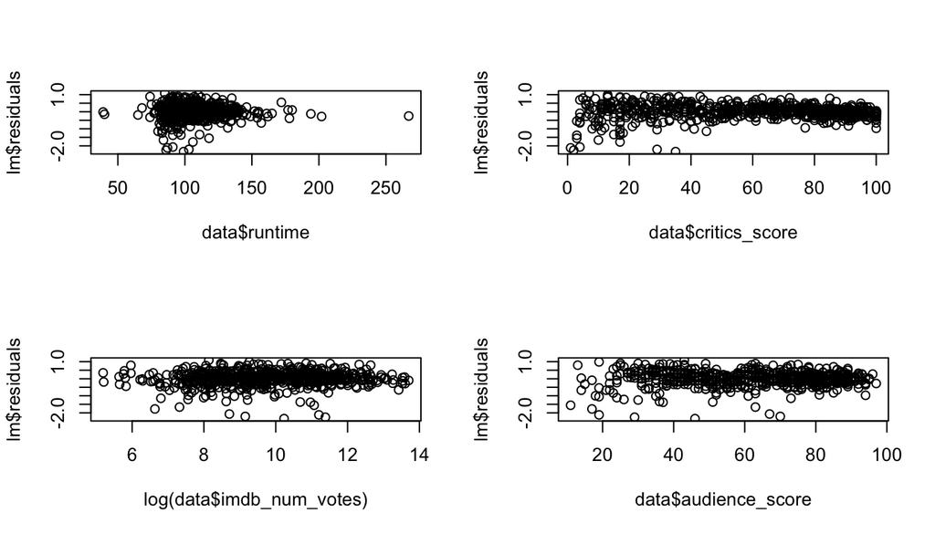

```r
# diagnostic plots
lm <- lm(imdb_rating ~ genre + runtime + thtr_rel_month + dvd_rel_day +
    imdb_num_votes + critics_rating + critics_score + audience_rating +
    audience_score, data = data)
layout(matrix(c(1,2,3,4),2,2)) # optional 4 graphs/page
plot(data$runtime, lm$residuals)
plot(log(data$imdb_num_votes), lm$residuals)
plot(data$critics_score, lm$residuals)
plot(data$audience_score, lm$residuals)
```

**result**: the residuals is randomly distributed near zero for all four numeric variable. So there are linear relationship between x and y.

Then, check other conditions.

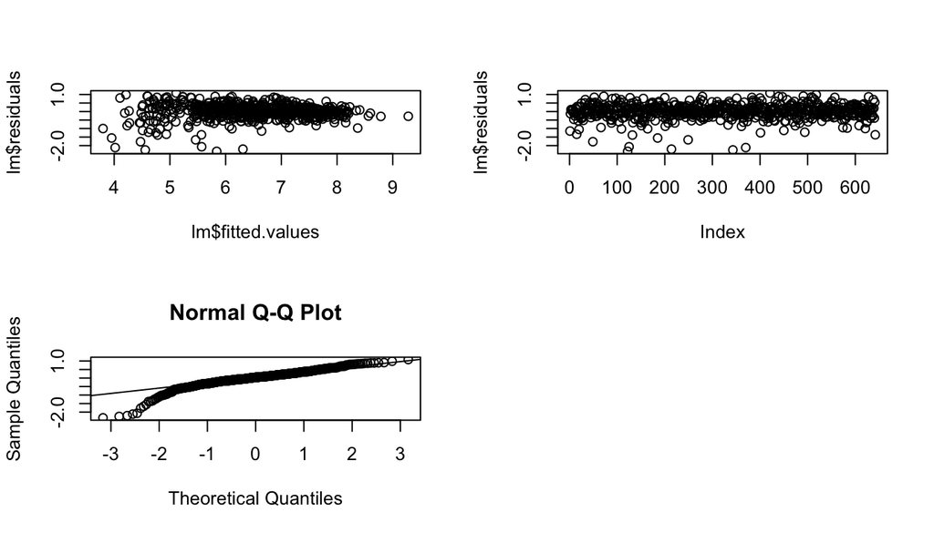

```r
layout(matrix(c(1,2,3,4),2,2))
plot(lm$fitted.values, lm$residuals)
qqnorm(lm$residuals)
qqline(lm$residuals)
plot(lm$residuals)
```

**Interpretation of model coefficients**

```r
summary(lm)
```

```
##
## Call:
## lm(formula = imdb_rating ~ genre + runtime + thtr_rel_month +
##     dvd_rel_day + imdb_num_votes + critics_rating + critics_score +
##     audience_rating + audience_score, data = data)
##
## Residuals:
##      Min       1Q   Median       3Q      Max
## -2.33974 -0.17744  0.03895  0.24379  1.08783
##
## Coefficients:
##                                  Estimate Std. Error t value Pr(>|t|)
## (Intercept)                     2.619e+00  1.727e-01  15.165  < 2e-16 ***
## genreAnimation                 -3.247e-01  1.598e-01  -2.032 0.042536 *
## genreArt House & International  3.937e-01  1.372e-01   2.869 0.004262 **
## genreComedy                    -1.340e-01  7.390e-02  -1.813 0.070242 .
## genreDocumentary                3.456e-01  9.415e-02   3.671 0.000262 ***
## genreDrama                      1.083e-01  6.423e-02   1.686 0.092300 .
## genreHorror                     8.018e-02  1.093e-01   0.734 0.463264
## genreMusical & Performing Arts  8.715e-02  1.446e-01   0.603 0.546957
## genreMystery & Suspense         2.672e-01  8.155e-02   3.277 0.001109 **
## genreOther                     -3.889e-02  1.257e-01  -0.309 0.757177
## genreScience Fiction & Fantasy -5.712e-02  1.673e-01  -0.341 0.732960
## runtime                         3.035e-03  1.049e-03   2.893 0.003951 **
## thtr_rel_month                  8.508e-03  5.092e-03   1.671 0.095227 .
## dvd_rel_day                     2.823e-03  1.997e-03   1.414 0.157977
## imdb_num_votes                  9.146e-07  1.928e-07   4.745 2.59e-06 ***
## critics_ratingFresh             8.550e-02  5.532e-02   1.546 0.122711
## critics_ratingRotten            3.530e-01  8.895e-02   3.968 8.08e-05 ***
## critics_score                   1.487e-02  1.497e-03   9.936  < 2e-16 ***
## audience_ratingUpright         -3.450e-01  7.161e-02  -4.818 1.82e-06 ***
## audience_score                  3.944e-02  2.043e-03  19.309  < 2e-16 ***
## ---
## Signif. codes:  0 '***' 0.001 '**' 0.01 '*' 0.05 '.' 0.1 ' ' 1
##
## Residual standard error: 0.4433 on 622 degrees of freedom
## Multiple R-squared:  0.8348, Adjusted R-squared:  0.8298
## F-statistic: 165.4 on 19 and 622 DF,  p-value: < 2.2e-16
```

Adjusted R-squared is 0.8298, so 82.98% variablity of the response variable is expalined by the model. Most coefficients in the model is statistical significiant refering to the p-value. For interpretation, take genre for example. Animation is rated lowwer with other variable remain constant.

## Part 5: Prediction

The final model is: imdb_rating ~ genre + runtime + thtr_rel_month + dvd_rel_day + imdb_num_votes + critics_rating + critics_score + audience_rating + audience_score

- genre: Action
- runtime: 118 min
- thtr_rel_month: 7
- dvd_rel_day: NA
- imdb_num_votes: 11843
- critics_rating: Fresh
- critics_score: 93
- audience_rating: Upright
- audience_score: 90

```r
newdata <- data.frame(genre = "Action & Adventure", runtime = 118, thtr_rel_month = 7, dvd_rel_day = 0, imdb_num_votes = 11843, critics_rating = "Fresh", critics_score = 93, audience_rating = "Upright", audience_score = 90)
predict(lm, newdata)
```

```
##        1
## 7.720703
```

The predicted score is 7.72, and the real score is 7.8. The result shows that the model made a very good prediction to the imdb score of the movie “Train to busan”.

## Part 6: Conclusion

linear regression model is powerful enough for movies’ scores prediction. Imdb rating is not only depended on subjective variables but also objective variables.